# 001538_catalyst_neuro_zhai_2025_figure_2GH_oepsc_analysis_ipynb

## Installing requirements

The cell below installs every Python package needed to run this notebook, at fully pinned versions, using [`uv`](https://github.com/astral-sh/uv) for fast resolution. In Colab the cell is collapsed by default — click the ▶ button to run it.

```python
# install cell skipped during CI (deps preinstalled into system Python)
```

> **⚠️ Restart runtime after install**

> The install may upgrade packages already loaded in the kernel. Go to **Runtime → Restart session**, then **Run all cells below** (skip this install cell on re-run).

# Reproducing Figure 2G-H: oEPSC Analysis

This notebook reproduces Figure 2G-H from **Zhai et al. 2025** comparing optogenetically evoked postsynaptic currents (oEPSCs) of dSPNs between the LID off-state and on-state in a Parkinson's disease model.

**Dataset**: DANDI:001538 - State-dependent modulation of spiny projection neurons controls levodopa-induced dyskinesia

**Analysis approach**:

- **Figure 2G**: Cumulative distribution of all individual oEPSC events
- **Figure 2H**: Box plot comparing the mean event amplitude of each cell
- **Event detection**: MAD-based noise estimation with ±5SD threshold
- **Conditions**: LID off-state vs LID on-state

## Setup and Data Loading

### Import Libraries and Configure Plotting Style

We use the same plotting parameters as the original publication to ensure visual consistency.

```python
import h5py
import matplotlib.pyplot as plt
import numpy as np
import remfile
import seaborn as sns
from dandi.dandiapi import DandiAPIClient
from pynwb import NWBHDF5IO
from scipy import stats
from tqdm import tqdm

# Set plotting style to match paper
plt.style.use('default')
sns.set_palette("Set2")

def setup_figure_style():
    """Setup matplotlib parameters to match paper style"""
    plt.rcParams.update({
        'font.size': 8,
        'axes.titlesize': 10,
        'axes.labelsize': 9,
        'xtick.labelsize': 8,
        'ytick.labelsize': 8,
        'legend.fontsize': 8,
        'figure.titlesize': 12,
        'axes.linewidth': 0.8,
        'axes.spines.top': False,
        'axes.spines.right': False,
        'xtick.major.width': 0.8,
        'ytick.major.width': 0.8,
        'xtick.minor.width': 0.6,
        'ytick.minor.width': 0.6,
    })

setup_figure_style()
print("Libraries imported and plotting style configured")
```

```
Libraries imported and plotting style configured
```

### Session ID Parsing and Filtering Functions

These utility functions parse the rich metadata encoded in DANDI file paths and find the dSPN patch-clamp files.

```python
# DANDI asset paths have the form sub-<subject_id>/sub-<subject_id>_ses-<session_id>_<modalities>.nwb, and the
# session ID has five parts: <cell type>++<state>++<pharmacology>++<genotype>++<date>.


def get_session_id(asset_path):
    """The session ID of a DANDI asset path, between '_ses-' and the modalities suffix."""
    file_name = asset_path.split("/")[-1].removesuffix(".nwb")
    return file_name.split("_ses-")[1].split("_")[0]


def get_modalities(asset_path):
    """The modalities suffix of a DANDI asset path, empty when the file has none."""
    after_session = asset_path.split("/")[-1].removesuffix(".nwb").split("_ses-")[1]
    return after_session.split("_")[1] if "_" in after_session else ""


def parse_session_id(session_id):
    """The five parts of a session ID."""
    cell_type, state, pharmacology, genotype, date = session_id.split("++")
    return {"cell_type": cell_type, "state": state, "pharmacology": pharmacology, "genotype": genotype, "date": date}


def is_dspn_patch_clamp(asset_path):
    """dSPN patch-clamp files: one mouse and recording day each, from Figure 1 (current clamp) and Figure 2 (Sr2+-oEPSC)."""
    return get_modalities(asset_path).startswith("icephys") and get_session_id(asset_path).startswith("dSPN++")
```

### Event Detection Functions

#### MAD-Based Event Detection

We use **Median Absolute Deviation (MAD)** for robust noise estimation, avoiding bias from the events themselves. Events are detected as deviations >5SD from baseline and nearby events are merged to handle multi-threshold crossings.

```python
def merge_nearby_events(event_times, event_amplitudes, merge_distance_ms=1.0):
    """Merge events within merge_distance_ms, keeping maximum amplitude."""
    if len(event_times) == 0:
        return [], []
    times = np.array(event_times)
    amplitudes = np.array(event_amplitudes)
    order = np.argsort(times)
    times = times[order]
    amplitudes = amplitudes[order]
    merged_times = []
    merged_amplitudes = []
    i = 0
    while i < len(times):
        current_time = times[i]
        j = i + 1
        max_amp = amplitudes[i]
        max_time = times[i]
        while j < len(times) and (times[j] - current_time) <= merge_distance_ms:
            if amplitudes[j] > max_amp:
                max_amp = float(amplitudes[j])
                max_time = float(times[j])
            j += 1
        merged_times.append(float(max_time))
        merged_amplitudes.append(float(max_amp))
        i = j
    return merged_times, merged_amplitudes

def process_nwb_file_for_events(nwbfile, detection_window_shift_ms=100, event_merge_distance_ms=1.0):
    """Event amplitudes of each cell of one Sr2+-oEPSC file, keyed by (cell, condition).

    Each cell has one VoltageClampSeries with its sweeps back to back; each row of the intracellular recordings table
    points to one sweep's slice, and the optogenetic pulses table has each sweep's LED flash. The paper counted events
    from 40 ms to 400 ms after the flash; the window here starts detection_window_shift_ms later, clear of the
    synchronous response.
    """
    recordings_df = nwbfile.intracellular_recordings.to_dataframe()
    pulses_df = nwbfile.intervals["optogenetic_pulses_table"].to_dataframe()

    amplitudes_per_cell = {}
    for _, row in recordings_df.iterrows():
        cell_id = int(row[("intracellular_recordings", "cell_id")])
        condition = row[("intracellular_recordings", "condition")]
        sweep_start = float(row[("intracellular_recordings", "sweep_start_time")])
        response = row[("responses", "response")]
        rate = round(1 / (response.timestamps[1] - response.timestamps[0]))

        # The flash of this sweep, on the sample grid, in ms from the sweep start
        flash = pulses_df[(pulses_df["cell_id"] == cell_id) & (pulses_df["start_time"] >= sweep_start)].iloc[0]
        flash_ms = round((float(flash["start_time"]) - sweep_start) * rate) / rate * 1000.0

        data_pA = np.asarray(response.data) * response.timeseries.conversion * 1e12
        t_ms = np.arange(response.count) / rate * 1000.0

        m = (t_ms >= flash_ms + 40.0 + detection_window_shift_ms) & (t_ms <= flash_ms + 400.0)
        if not np.any(m):
            continue
        seg = data_pA[m]
        seg_t = t_ms[m]

        noise_median = float(np.median(seg))
        mad = float(np.median(np.abs(seg - noise_median)))
        mad_std = mad * 1.4826

        thr_pos = noise_median + 5.0 * mad_std
        thr_neg = noise_median - 5.0 * mad_std

        idx_pos = np.where(seg > thr_pos)[0]
        idx_neg = np.where(seg < thr_neg)[0]

        pos_t, pos_a = merge_nearby_events(seg_t[idx_pos], seg[idx_pos] - noise_median, event_merge_distance_ms)
        neg_t, neg_a = merge_nearby_events(seg_t[idx_neg], noise_median - seg[idx_neg], event_merge_distance_ms)

        cell = f"{nwbfile.subject.subject_id} cell {cell_id}"
        amplitudes_per_cell.setdefault((cell, condition), []).extend(pos_a + neg_a)

    return amplitudes_per_cell
```

### Load DANDI Dataset

Connect to DANDI. The Sr2+-oEPSC recordings of dSPNs are the dSPN patch-clamp files with voltage-clamp series (the others are the current-clamp recordings of Figure 1).

```python
dandiset = DandiAPIClient().get_dandiset("001538", "0.261124.1858")
assets = {asset.path: asset for asset in dandiset.get_assets() if asset.path.endswith(".nwb")}
print(f"{len(assets)} NWB files")


def open_nwbfile(asset_path):
    """Stream one NWB file from DANDI without downloading it."""
    url = assets[asset_path].get_content_url(follow_redirects=1, strip_query=True)
    io = NWBHDF5IO(file=h5py.File(remfile.File(url), "r"), load_namespaces=True)
    return io.read()
```

```
391 NWB files
```

## Data Processing and Event Detection

### Process All NWB Files

We process each cell to extract oEPSC events, collecting both:

- **Individual events**: For cumulative distribution analysis
- **Cell means**: For box plot comparison of the mean response of each cell

```python
# Initialize data collections
all_events = {"LID off-state": [], "LID on-state": []}  # All individual events for cumulative plot
cell_means = {"LID off-state": [], "LID on-state": []}  # Mean responses per cell for box plot

dspn_paths = [asset_path for asset_path in assets if is_dspn_patch_clamp(asset_path)]
for asset_path in tqdm(dspn_paths, desc="dSPN patch-clamp files"):
    nwbfile = open_nwbfile(asset_path)
    if not any(name.startswith("VoltageClampSeries") for name in nwbfile.acquisition):
        continue  # current-clamp recordings of Figure 1
    for (cell, condition), amplitudes in process_nwb_file_for_events(nwbfile).items():
        all_events[condition].extend(amplitudes)
        if len(amplitudes) > 0:
            cell_means[condition].append(np.mean(amplitudes))

all_offstate_events, all_onstate_events = all_events["LID off-state"], all_events["LID on-state"]
offstate_cell_means, onstate_cell_means = cell_means["LID off-state"], cell_means["LID on-state"]

print(f"\nData collection complete:")
print(f"  LID off-state: {len(all_offstate_events)} events from {len(offstate_cell_means)} cells")
print(f"  LID on-state: {len(all_onstate_events)} events from {len(onstate_cell_means)} cells")
```

```
Data collection complete:
  LID off-state: 608 events from 10 cells
  LID on-state: 664 events from 8 cells
```

## Figure 2G: Cumulative Distribution Plot

### Individual Event Analysis

This plot shows the cumulative distribution of **all individual oEPSC events** across all experimental sessions, allowing comparison of the full event amplitude distributions between OffState and OnState conditions.

```
=== FIGURE 2G: CUMULATIVE DISTRIBUTION ANALYSIS ===
OffState events: 608
  Mean: 16.09 ± 6.07 pA
  Median: 14.92 pA
  25th percentile: 11.58 pA
  75th percentile: 19.49 pA

OnState events: 664
  Mean: 23.20 ± 9.83 pA
  Median: 21.24 pA
  25th percentile: 16.10 pA
  75th percentile: 27.53 pA

Comparison:
  Mean fold change (OnState/OffState): 1.442
  Median fold change: 1.423

Kolmogorov-Smirnov test:
  KS statistic: 0.3377
  p-value: 1.32e-32
  Significantly different: Yes
```

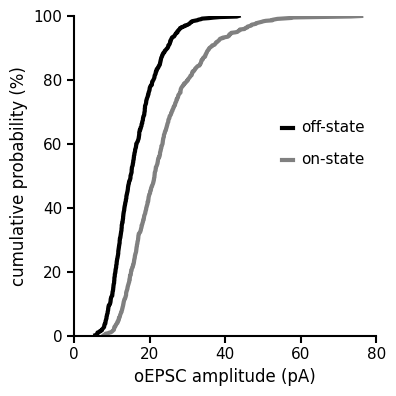

```python
# Create cumulative distribution plot
fig, ax = plt.subplots(1, 1, figsize=(4, 4))  # Square aspect ratio like the reference

# Convert to numpy arrays
offstate_amplitudes = np.array(all_offstate_events)
onstate_amplitudes = np.array(all_onstate_events)

# Sort the data
offstate_sorted = np.sort(offstate_amplitudes)
onstate_sorted = np.sort(onstate_amplitudes)

# Calculate cumulative probabilities as percentages
offstate_cumulative = np.arange(1, len(offstate_sorted) + 1) / len(offstate_sorted) * 100
onstate_cumulative = np.arange(1, len(onstate_sorted) + 1) / len(onstate_sorted) * 100

# Plot with paper-style colors and thickness - match reference styling
ax.plot(offstate_sorted, offstate_cumulative, color='black', linewidth=3)
ax.plot(onstate_sorted, onstate_cumulative, color='gray', linewidth=3)

# Formatting to match reference image
ax.set_xlabel('oEPSC amplitude (pA)', fontsize=12, fontweight='normal')
ax.set_ylabel('cumulative probability (%)', fontsize=12, fontweight='normal')

# Set axis limits and ticks to match paper
ax.set_xlim(0, 80)
ax.set_ylim(0, 100)
ax.set_xticks([0, 20, 40, 60, 80])
ax.set_yticks([0, 20, 40, 60, 80, 100])

# Style the axes to match reference
ax.spines['top'].set_visible(False)
ax.spines['right'].set_visible(False)
ax.spines['left'].set_linewidth(1.5)
ax.spines['bottom'].set_linewidth(1.5)
ax.tick_params(axis='both', which='major', labelsize=11, width=1.5, length=5)

# Add labels with line markers in middle right
ax.plot([55, 58], [65, 65], color='black', linewidth=3)
ax.text(60, 65, 'off-state', fontsize=11, ha='left', va='center')

ax.plot([55, 58], [55, 55], color='gray', linewidth=3)
ax.text(60, 55, 'on-state', fontsize=11, ha='left', va='center')

# Calculate and display statistics
off_median = np.median(offstate_amplitudes)
on_median = np.median(onstate_amplitudes)
off_mean = np.mean(offstate_amplitudes)
on_mean = np.mean(onstate_amplitudes)

print("=== FIGURE 2G: CUMULATIVE DISTRIBUTION ANALYSIS ===")
print(f"OffState events: {len(offstate_amplitudes)}")
print(f"  Mean: {off_mean:.2f} ± {np.std(offstate_amplitudes):.2f} pA")
print(f"  Median: {off_median:.2f} pA")
print(f"  25th percentile: {np.percentile(offstate_amplitudes, 25):.2f} pA")
print(f"  75th percentile: {np.percentile(offstate_amplitudes, 75):.2f} pA")

print(f"\nOnState events: {len(onstate_amplitudes)}")
print(f"  Mean: {on_mean:.2f} ± {np.std(onstate_amplitudes):.2f} pA")
print(f"  Median: {on_median:.2f} pA")
print(f"  25th percentile: {np.percentile(onstate_amplitudes, 25):.2f} pA")
print(f"  75th percentile: {np.percentile(onstate_amplitudes, 75):.2f} pA")

print(f"\nComparison:")
print(f"  Mean fold change (OnState/OffState): {on_mean/off_mean:.3f}")
print(f"  Median fold change: {on_median/off_median:.3f}")

# Kolmogorov-Smirnov test
ks_stat, ks_p = stats.ks_2samp(offstate_amplitudes, onstate_amplitudes)
print(f"\nKolmogorov-Smirnov test:")
print(f"  KS statistic: {ks_stat:.4f}")
print(f"  p-value: {ks_p:.2e}")
print(f"  Significantly different: {'Yes' if ks_p < 0.05 else 'No'}")

plt.tight_layout()
plt.show()
```

## Figure 2H: Box Plot Comparison

### Mean Response Per Cell Analysis

This box plot compares the **mean event amplitude of each cell**, treating each cell as one data point as the paper does. This approach controls for differences in the number of events recorded per cell.

```
=== FIGURE 2H: BOX PLOT STATISTICAL ANALYSIS ===

LID off-state cell means (n=10):
  Median: 15.79 pA
  Mean: 16.09 ± 1.77 pA
  IQR: 15.13 - 17.53 pA
  Range: 12.73 - 18.68 pA

LID on-state cell means (n=8):
  Median: 22.39 pA
  Mean: 23.66 ± 5.49 pA
  IQR: 19.38 - 28.59 pA
  Range: 16.33 - 32.50 pA

Comparison:
  Median fold change: 1.418
  Mean fold change: 1.471
  Difference in medians: 6.60 pA
  Difference in means: 7.57 pA

Mann-Whitney U test (non-parametric):
  U statistic: 6.00
  p-value: 1.37e-03
  Significantly different: Yes

Welch's t-test (unequal variances):
  t statistic: -3.5078
  p-value: 7.77e-03
  Significantly different: Yes

Effect size (Cohen's d): 1.957
  Effect size interpretation: large
```

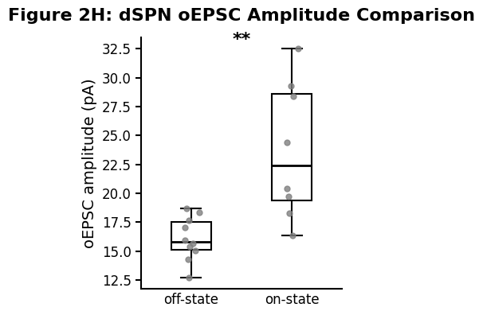

```python
# Create box plot
fig, ax = plt.subplots(1, 1, figsize=(3.5, 4.0))

# Convert to numpy arrays
offstate_means = np.array(offstate_cell_means)
onstate_means = np.array(onstate_cell_means)

# Prepare data for box plot
box_data = [offstate_means, onstate_means]
positions = [1, 2]

# Create box plot with paper-style formatting
bp = ax.boxplot(box_data, positions=positions, patch_artist=True,
               widths=0.4, showfliers=True, notch=False,
               medianprops=dict(color='black', linewidth=2),
               whiskerprops=dict(color='black', linewidth=1.5),
               capprops=dict(color='black', linewidth=1.5),
               flierprops=dict(marker='o', markersize=4, alpha=0.7, markerfacecolor='gray'))

# Customize box colors to match paper (both white/light gray)
colors = ['white', 'white']
for patch, color in zip(bp['boxes'], colors):
    patch.set_facecolor(color)
    patch.set_edgecolor('black')
    patch.set_linewidth(1.5)

# Add individual data points as gray dots
for i, data in enumerate(box_data):
    # Add some jitter for visibility
    x_vals = np.random.normal(positions[i], 0.04, size=len(data))
    ax.scatter(x_vals, data, color='gray', s=25, alpha=0.8, zorder=3)

# Calculate statistics for significance annotation
off_mean = np.mean(offstate_means)
on_mean = np.mean(onstate_means)

# Statistical test
u_stat, u_p = stats.mannwhitneyu(offstate_means, onstate_means,
                                alternative='two-sided')

# Add significance annotation (**) at the top
y_max = max(np.max(offstate_means), np.max(onstate_means))
y_sig = y_max + 0.8
ax.text(1.5, y_sig, '**', ha='center', va='center', fontsize=16, fontweight='bold')

# Formatting to match paper exactly
ax.set_xticks([1, 2])
ax.set_xticklabels(['off-state', 'on-state'], fontsize=14)
ax.set_ylabel('oEPSC amplitude (pA)', fontsize=14, fontweight='normal')
ax.set_title('Figure 2H: dSPN oEPSC Amplitude Comparison', fontsize=16, fontweight='bold', pad=15)

# Style the axes
ax.spines['top'].set_visible(False)
ax.spines['right'].set_visible(False)
ax.spines['left'].set_linewidth(1.5)
ax.spines['bottom'].set_linewidth(1.5)
ax.tick_params(axis='both', which='major', labelsize=12, width=1.5, length=5)
ax.tick_params(axis='x', which='major', length=0)  # Remove x-axis tick marks

# Calculate and display statistics
off_median = np.median(offstate_means)
on_median = np.median(onstate_means)

print("=== FIGURE 2H: BOX PLOT STATISTICAL ANALYSIS ===")
print(f"\nLID off-state cell means (n={len(offstate_means)}):")
print(f"  Median: {off_median:.2f} pA")
print(f"  Mean: {off_mean:.2f} ± {np.std(offstate_means):.2f} pA")
print(f"  IQR: {np.percentile(offstate_means, 25):.2f} - {np.percentile(offstate_means, 75):.2f} pA")
print(f"  Range: {np.min(offstate_means):.2f} - {np.max(offstate_means):.2f} pA")

print(f"\nLID on-state cell means (n={len(onstate_means)}):")
print(f"  Median: {on_median:.2f} pA")
print(f"  Mean: {on_mean:.2f} ± {np.std(onstate_means):.2f} pA")
print(f"  IQR: {np.percentile(onstate_means, 25):.2f} - {np.percentile(onstate_means, 75):.2f} pA")
print(f"  Range: {np.min(onstate_means):.2f} - {np.max(onstate_means):.2f} pA")

print(f"\nComparison:")
print(f"  Median fold change: {on_median/off_median:.3f}")
print(f"  Mean fold change: {on_mean/off_mean:.3f}")
print(f"  Difference in medians: {on_median - off_median:.2f} pA")
print(f"  Difference in means: {on_mean - off_mean:.2f} pA")

print(f"\nMann-Whitney U test (non-parametric):")
print(f"  U statistic: {u_stat:.2f}")
print(f"  p-value: {u_p:.2e}")
print(f"  Significantly different: {'Yes' if u_p < 0.05 else 'No'}")

# Welch's t-test (unequal variances)
t_stat, t_p = stats.ttest_ind(offstate_means, onstate_means,
                            equal_var=False)
print(f"\nWelch's t-test (unequal variances):")
print(f"  t statistic: {t_stat:.4f}")
print(f"  p-value: {t_p:.2e}")
print(f"  Significantly different: {'Yes' if t_p < 0.05 else 'No'}")

# Effect size (Cohen's d)
pooled_std = np.sqrt(((len(offstate_means)-1)*np.var(offstate_means) +
                    (len(onstate_means)-1)*np.var(onstate_means)) /
                   (len(offstate_means) + len(onstate_means) - 2))
cohens_d = (on_mean - off_mean) / pooled_std
print(f"\nEffect size (Cohen's d): {cohens_d:.3f}")

if abs(cohens_d) < 0.2:
    effect_size = "negligible"
elif abs(cohens_d) < 0.5:
    effect_size = "small"
elif abs(cohens_d) < 0.8:
    effect_size = "medium"
else:
    effect_size = "large"
print(f"  Effect size interpretation: {effect_size}")

plt.tight_layout()
plt.show()
```

## Summary

### Key Findings

This analysis reproduces the key findings from **Figure 2G-H** of Zhai et al. 2025:

1. **Cumulative Distribution (Figure 2G)**: Shows the distribution of all individual oEPSC events across experimental conditions
2. **Box Plot Comparison (Figure 2H)**: Compares the mean event amplitude of each cell

### Methodological Notes

- **Event Detection**: MAD-based noise estimation with ±5SD threshold
- **Artifact Avoidance**: 100ms detection window shift to avoid stimulation artifacts
- **Event Merging**: 1ms window to handle multi-threshold crossings from single events
- **Statistical Testing**: Both parametric and non-parametric tests for robust comparison

### Biological Significance

The analysis reveals how L-DOPA treatment (OnState) affects optogenetically-evoked synaptic responses in striatal neurons, providing insights into the synaptic mechanisms underlying levodopa-induced dyskinesia in Parkinson's disease.